# Practical Machine Learning Coursework

Gashnikov

## Data

### Load

The data for this work have been taken from [Human Activity Recognition project](http://groupware.les.inf.puc-rio.br/har)

There are 2 datasets: train and test  
Train has 19622 rows and 159 features.  
‘classe’ column contains classes that should be predicted by model.  
Other columns contains features to possibly include in model.  
Train and test datasets have the same set of columns besides last one - in train it is ‘classe’ and there is target class for training in test there is problem_id - just id of test row.

### Features selection

First we should dismiss features that should not be in predictors for some reason:  
X - just rownumber - it must not influence result  
user_name - we should not take in account individual differences in our model  
raw_timestamp_part_1, raw_timestamp_part_2, cvtd_timestamp - no timestamps  
new_window, num_window - it seems it artefact from rolling window method

```r
train = subset(train, select=c(-X, -user_name, -raw_timestamp_part_1, -raw_timestamp_part_2, -cvtd_timestamp, -new_window, -num_window))
```

### We should fill NA’s - lets do it:

```r
library(caret)
target <- train$classe
target <- factor(x = target)
train <- subset(train, select=-classe)
train_m <- data.matrix(train)
train_m[is.na(train_m)] <- 0
```

### Division for crossvalidation

```r
inTrain <- createDataPartition(target, p=0.75, list=FALSE)
training_x <- train_m[inTrain, ]
verification_x <- train_m[-inTrain, ]
training_y <- target[inTrain]
verification_y <- target[-inTrain]

#find variated features in set
variated = apply(training_x, 2, var) > 0.1
```

## Model&Run

Random forest training with PCA(0.95):

```r
require('doMC')
registerDoMC(cores = 4)
if(!'modFit1' %in% ls()) {
    modFit1 <- train(data.frame(training_x[, variated]), training_y, method="rf", preProcess='pca')
    }
pred <- predict(modFit1, newdata=data.frame(verification_x[, variated]))
confusionMatrix(verification_y, pred)
```

```
## Confusion Matrix and Statistics
##
##           Reference
## Prediction    A    B    C    D    E
##          A 1375   11    2    2    5
##          B   28  902   15    0    4
##          C    6   20  815   10    4
##          D    0    4   34  760    6
##          E    0    7    3   15  876
##
## Overall Statistics
##
##                Accuracy : 0.964
##                  95% CI : (0.959, 0.969)
##     No Information Rate : 0.287
##     P-Value [Acc > NIR] : < 2e-16
##
##                   Kappa : 0.955
##  Mcnemar's Test P-Value : 2.5e-05
##
## Statistics by Class:
##
##                      Class: A Class: B Class: C Class: D Class: E
## Sensitivity             0.976    0.956    0.938    0.966    0.979
## Specificity             0.994    0.988    0.990    0.989    0.994
## Pos Pred Value          0.986    0.950    0.953    0.945    0.972
## Neg Pred Value          0.990    0.989    0.987    0.993    0.995
## Prevalence              0.287    0.192    0.177    0.160    0.183
## Detection Rate          0.280    0.184    0.166    0.155    0.179
## Detection Prevalence    0.284    0.194    0.174    0.164    0.184
## Balanced Accuracy       0.985    0.972    0.964    0.978    0.986
```

```r
table(verification_y, pred)
```

```
##               pred
## verification_y    A    B    C    D    E
##              A 1375   11    2    2    5
##              B   28  902   15    0    4
##              C    6   20  815   10    4
##              D    0    4   34  760    6
##              E    0    7    3   15  876
```

Visualize:

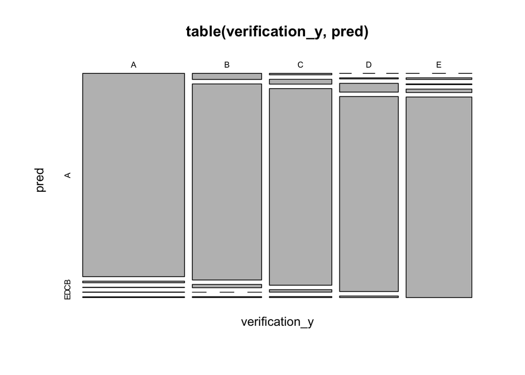

```r
mosaicplot(table(verification_y, pred))
```

## Predict on test data

```r
#normalize test
test = subset(test, select=c(-X, -user_name, -raw_timestamp_part_1, -raw_timestamp_part_2, -cvtd_timestamp, -new_window, -num_window, -problem_id))
test_m <- data.matrix(test)
test_m[is.na(test_m)] <- 0

#predict
pred_test <- predict(modFit1, newdata=data.frame(test_m[, variated]))

#save results
pml_write_files = function(x){
  n = length(x)
  for(i in 1:n){
    filename = paste0("problem_id_",i,".txt")
    write.table(x[i],file=filename,quote=FALSE,row.names=FALSE,col.names=FALSE)
  }
}

setwd('../pred_data')
pml_write_files(as.character(pred_test))
setwd('../pmlcw')
```

Got 20 from 20!

# Citation

[1] Velloso, E.; Bulling, A.; Gellersen, H.; Ugulino, W.; Fuks, H. Qualitative Activity Recognition of Weight Lifting Exercises. Proceedings of 4th International Conference in Cooperation with SIGCHI (Augmented Human ’13) . Stuttgart, Germany: ACM SIGCHI, 2013.

Read more: http://groupware.les.inf.puc-rio.br/har#weight_lifting_exercises#ixzz3DpOlOXOp